# Binary-Class Tabular Model for Liver Disease Patients Using Python and TensorFlow Decision Forests

### November 1, 2022

SUMMARY: The project aims to construct a predictive model using various machine learning algorithms and document the end-to-end steps using a template. The Liver Disease Patients dataset is a binary-class modeling situation where we attempt to predict one of two possible outcomes.

INTRODUCTION: This dataset contains over 30,000 cases of liver disease diagnosis results. The researcher trained machine learning models using this dataset to test the feasibility of applying machine learning techniques for making diagnostic predictions.

ANALYSIS: The Gradient Boosted Trees model performed the best with the training dataset. The model achieved an average accuracy benchmark of 99.81% using the 10-fold cross-validation method.

CONCLUSION: In this iteration, the Gradient Boosted Trees model appeared to be a suitable algorithm for modeling this dataset.

Dataset Used: Liver Disease Patients Dataset

Dataset ML Model: Binary-Class classification with numerical and categorical features

Dataset Reference: https://www.kaggle.com/datasets/abhi8923shriv/liver-disease-patient-dataset

One source of potential performance benchmarks: https://www.kaggle.com/datasets/abhi8923shriv/liver-disease-patient-dataset/code

## Task 1 - Prepare Environment

```python
# Install TensorFlow Decision Forests
!pip3 install tensorflow_decision_forests --upgrade
```

[output not shown]

```python
# Retrieve the CPU information
ncpu = !nproc
print("The number of available CPUs is:", ncpu[0])
```

```
The number of available CPUs is: 2
```

### 1.a) Load libraries and modules

```python
# Set the random seed number for reproducible results
RNG_SEED = 888
```

```python
import random
random.seed(RNG_SEED)
import numpy as np
np.random.seed(RNG_SEED)
import pandas as pd
import seaborn as sns
import matplotlib
import matplotlib.pyplot as plt
import os
import sys
import math
# import boto3
import zipfile
import urllib
from datetime import datetime
from sklearn import preprocessing
from sklearn.model_selection import train_test_split
from sklearn.model_selection import RepeatedKFold
from sklearn.metrics import classification_report
from sklearn.metrics import confusion_matrix
from sklearn.metrics import accuracy_score
from sklearn.pipeline import Pipeline
from sklearn import compose
from sklearn import impute
from sklearn import metrics
import tensorflow as tf
tf.random.set_seed(RNG_SEED)
# from tensorflow import keras
import tensorflow_decision_forests as tfdf
```

### 1.b) Set up the controlling parameters and functions

```python
# Begin the timer for the script processing
start_time_script = datetime.now()

# Set up the number of CPU cores available for multi-thread processing
N_JOBS = 1

# Set up the flag to stop sending progress emails (setting to True will send status emails!)
NOTIFY_STATUS = False

# Set the percentage sizes for splitting the dataset
TEST_SET_RATIO = 0.1
VAL_SET_RATIO = 0.1

# Set the name for the class/label column
ORIGINAL_LABEL = 'Result'
CLASS_COLUMN = 'target'

# Set the number of folds for cross validation
N_FOLDS = 10
N_ITERATIONS = 1

# Set various default modeling parameters
DEFAULT_METRICS = ["accuracy", tf.keras.metrics.SparseCategoricalCrossentropy()]

# Define the directory locations and file names
TRAIN_DATASET = 'LPD_train.csv'

# Print out the TensorFlow version for confirmation
print('TensorFlow version:', tf.__version__)

# Check the version of TensorFlow Decision Forests
print("Found TensorFlow Decision Forests v" + tfdf.__version__)
```

```
TensorFlow version: 2.10.0
Found TensorFlow Decision Forests v1.0.1
```

```python
# Set up the email notification function
def status_notify(msg_text):
    access_key = os.environ.get('SNS_ACCESS_KEY')
    secret_key = os.environ.get('SNS_SECRET_KEY')
    aws_region = os.environ.get('SNS_AWS_REGION')
    topic_arn = os.environ.get('SNS_TOPIC_ARN')
    if (access_key is None) or (secret_key is None) or (aws_region is None):
        sys.exit("Incomplete notification setup info. Script Processing Aborted!!!")
    sns = boto3.client('sns', aws_access_key_id=access_key, aws_secret_access_key=secret_key, region_name=aws_region)
    response = sns.publish(TopicArn=topic_arn, Message=msg_text)
    if response['ResponseMetadata']['HTTPStatusCode'] != 200 :
        print('Status notification not OK with HTTP status code:', response['ResponseMetadata']['HTTPStatusCode'])
```

```python
if NOTIFY_STATUS: status_notify("Task 1 - Prepare Environment has begun! " + datetime.now().strftime('%a %B %d, %Y %I:%M:%S %p'))
```

### 1.c) Load dataset

```python
dataset_path = 'https://dainesanalytics.com/datasets/kaggle-abhi8923shriv-liver-disease-patient/LPD_train.csv'
df_dataset_import = pd.read_csv(dataset_path)

# Take a peek at the dataframe after import
print(df_dataset_import.head())
```

```
    Age  Gender  Total_Bilirubin  Direct_Bilirubin  \
0  65.0  Female              0.7               0.1
1  62.0    Male             10.9               5.5
2  62.0    Male              7.3               4.1
3  58.0    Male              1.0               0.4
4  72.0    Male              3.9               2.0

   Alkphos_Alkaline_Phosphotase  Sgpt_Alamine_Aminotransferase  \
0                         187.0                           16.0
1                         699.0                           64.0
2                         490.0                           60.0
3                         182.0                           14.0
4                         195.0                           27.0

   Sgot_Aspartate_Aminotransferase  Total_Protiens  ALB_Albumin  \
0                             18.0             6.8          3.3
1                            100.0             7.5          3.2
2                             68.0             7.0          3.3
3                             20.0             6.8          3.4
4                             59.0             7.3          2.4

   Albumin_Globulin_Ratio  Result
0                    0.90       1
1                    0.74       1
2                    0.89       1
3                    1.00       1
4                    0.40       1
```

```python
df_dataset_import.info(verbose=True)
```

```
<class 'pandas.core.frame.DataFrame'>
RangeIndex: 30691 entries, 0 to 30690
Data columns (total 11 columns):
 #   Column                           Non-Null Count  Dtype
---  ------                           --------------  -----
 0   Age                              30689 non-null  float64
 1   Gender                           29789 non-null  object
 2   Total_Bilirubin                  30043 non-null  float64
 3   Direct_Bilirubin                 30130 non-null  float64
 4   Alkphos_Alkaline_Phosphotase     29895 non-null  float64
 5   Sgpt_Alamine_Aminotransferase    30153 non-null  float64
 6   Sgot_Aspartate_Aminotransferase  30229 non-null  float64
 7   Total_Protiens                   30228 non-null  float64
 8   ALB_Albumin                      30197 non-null  float64
 9   Albumin_Globulin_Ratio           30132 non-null  float64
 10  Result                           30691 non-null  int64
dtypes: float64(9), int64(1), object(1)
memory usage: 2.6+ MB
```

```python
print(df_dataset_import.describe())
```

```
                Age  Total_Bilirubin  Direct_Bilirubin  \
count  30689.000000     30043.000000      30130.000000
mean      44.107205         3.370319          1.528042
std       15.981043         6.255522          2.869592
min        4.000000         0.400000          0.100000
25%       32.000000         0.800000          0.200000
50%       45.000000         1.000000          0.300000
75%       55.000000         2.700000          1.300000
max       90.000000        75.000000         19.700000

       Alkphos_Alkaline_Phosphotase  Sgpt_Alamine_Aminotransferase  \
count                  29895.000000                   30153.000000
mean                     289.075364                      81.488641
std                      238.537589                     182.158850
min                       63.000000                      10.000000
25%                      175.000000                      23.000000
50%                      209.000000                      35.000000
75%                      298.000000                      62.000000
max                     2110.000000                    2000.000000

       Sgot_Aspartate_Aminotransferase  Total_Protiens   ALB_Albumin  \
count                     30229.000000    30228.000000  30197.000000
mean                        111.469979        6.480237      3.130142
std                         280.851078        1.081980      0.792281
min                          10.000000        2.700000      0.900000
25%                          26.000000        5.800000      2.600000
50%                          42.000000        6.600000      3.100000
75%                          88.000000        7.200000      3.800000
max                        4929.000000        9.600000      5.500000

       Albumin_Globulin_Ratio        Result
count            30132.000000  30691.000000
mean                 0.943467      1.285882
std                  0.323164      0.451841
min                  0.300000      1.000000
25%                  0.700000      1.000000
50%                  0.900000      1.000000
75%                  1.100000      2.000000
max                  2.800000      2.000000
```

```python
print(df_dataset_import.isnull().sum())
print('Total number of NaN in the dataframe: ', df_dataset_import.isnull().sum().sum())
```

```
Age                                  2
Gender                             902
Total_Bilirubin                    648
Direct_Bilirubin                   561
Alkphos_Alkaline_Phosphotase       796
Sgpt_Alamine_Aminotransferase      538
Sgot_Aspartate_Aminotransferase    462
Total_Protiens                     463
ALB_Albumin                        494
Albumin_Globulin_Ratio             559
Result                               0
dtype: int64
Total number of NaN in the dataframe:  5425
```

```python
# Get grouping size for the target variable
print(df_dataset_import.groupby(ORIGINAL_LABEL).size())
```

```
Result
1    21917
2     8774
dtype: int64
```

### 1.d) Data Cleaning

```python
# Standardize the class column to the name of targetVar if required
df_dataset_import = df_dataset_import.rename(columns={ORIGINAL_LABEL: CLASS_COLUMN})

# Take a peek at the dataframe after cleaning
print(df_dataset_import.head())
```

```
    Age  Gender  Total_Bilirubin  Direct_Bilirubin  \
0  65.0  Female              0.7               0.1
1  62.0    Male             10.9               5.5
2  62.0    Male              7.3               4.1
3  58.0    Male              1.0               0.4
4  72.0    Male              3.9               2.0

   Alkphos_Alkaline_Phosphotase  Sgpt_Alamine_Aminotransferase  \
0                         187.0                           16.0
1                         699.0                           64.0
2                         490.0                           60.0
3                         182.0                           14.0
4                         195.0                           27.0

   Sgot_Aspartate_Aminotransferase  Total_Protiens  ALB_Albumin  \
0                             18.0             6.8          3.3
1                            100.0             7.5          3.2
2                             68.0             7.0          3.3
3                             20.0             6.8          3.4
4                             59.0             7.3          2.4

   Albumin_Globulin_Ratio  target
0                    0.90       1
1                    0.74       1
2                    0.89       1
3                    1.00       1
4                    0.40       1
```

```python
df_dataset_import.info(verbose=True)
```

```
<class 'pandas.core.frame.DataFrame'>
RangeIndex: 30691 entries, 0 to 30690
Data columns (total 11 columns):
 #   Column                           Non-Null Count  Dtype
---  ------                           --------------  -----
 0   Age                              30689 non-null  float64
 1   Gender                           29789 non-null  object
 2   Total_Bilirubin                  30043 non-null  float64
 3   Direct_Bilirubin                 30130 non-null  float64
 4   Alkphos_Alkaline_Phosphotase     29895 non-null  float64
 5   Sgpt_Alamine_Aminotransferase    30153 non-null  float64
 6   Sgot_Aspartate_Aminotransferase  30229 non-null  float64
 7   Total_Protiens                   30228 non-null  float64
 8   ALB_Albumin                      30197 non-null  float64
 9   Albumin_Globulin_Ratio           30132 non-null  float64
 10  target                           30691 non-null  int64
dtypes: float64(9), int64(1), object(1)
memory usage: 2.6+ MB
```

```python
print(df_dataset_import.describe())
```

```
                Age  Total_Bilirubin  Direct_Bilirubin  \
count  30689.000000     30043.000000      30130.000000
mean      44.107205         3.370319          1.528042
std       15.981043         6.255522          2.869592
min        4.000000         0.400000          0.100000
25%       32.000000         0.800000          0.200000
50%       45.000000         1.000000          0.300000
75%       55.000000         2.700000          1.300000
max       90.000000        75.000000         19.700000

       Alkphos_Alkaline_Phosphotase  Sgpt_Alamine_Aminotransferase  \
count                  29895.000000                   30153.000000
mean                     289.075364                      81.488641
std                      238.537589                     182.158850
min                       63.000000                      10.000000
25%                      175.000000                      23.000000
50%                      209.000000                      35.000000
75%                      298.000000                      62.000000
max                     2110.000000                    2000.000000

       Sgot_Aspartate_Aminotransferase  Total_Protiens   ALB_Albumin  \
count                     30229.000000    30228.000000  30197.000000
mean                        111.469979        6.480237      3.130142
std                         280.851078        1.081980      0.792281
min                          10.000000        2.700000      0.900000
25%                          26.000000        5.800000      2.600000
50%                          42.000000        6.600000      3.100000
75%                          88.000000        7.200000      3.800000
max                        4929.000000        9.600000      5.500000

       Albumin_Globulin_Ratio        target
count            30132.000000  30691.000000
mean                 0.943467      1.285882
std                  0.323164      0.451841
min                  0.300000      1.000000
25%                  0.700000      1.000000
50%                  0.900000      1.000000
75%                  1.100000      2.000000
max                  2.800000      2.000000
```

```python
print(df_dataset_import.isnull().sum())
print('Total number of NaN in the dataframe: ', df_dataset_import.isnull().sum().sum())
```

```
Age                                  2
Gender                             902
Total_Bilirubin                    648
Direct_Bilirubin                   561
Alkphos_Alkaline_Phosphotase       796
Sgpt_Alamine_Aminotransferase      538
Sgot_Aspartate_Aminotransferase    462
Total_Protiens                     463
ALB_Albumin                        494
Albumin_Globulin_Ratio             559
target                               0
dtype: int64
Total number of NaN in the dataframe:  5425
```

```python
# Get grouping size for the target variable
print(df_dataset_import.groupby(CLASS_COLUMN).size())
```

```
target
1    21917
2     8774
dtype: int64
```

### 1.e) Splitting Data into Sets

```python
# Use variable total_column_count to hold the number of columns in the dataframe
total_column_count = len(df_dataset_import.columns)

# Set up variable total_feature_count for the total number of attribute columns
total_feature_count = total_column_count-1

# We create attribute-only and target-only datasets (df_features_train and df_target_train)
df_target_train = df_dataset_import['target']
df_features_train = df_dataset_import.drop(['target'], axis=1)

print("df_dataset_import.shape: {} df_features_train.shape: {} df_target_train.shape: {}".format(df_dataset_import.shape, df_features_train.shape, df_target_train.shape))
```

```
df_dataset_import.shape: (30691, 11) df_features_train.shape: (30691, 10) df_target_train.shape: (30691,)
```

### 1.f) Set up the parameters for data visualization

```python
# Set up the number of row and columns for visualization display. display_rows * display_columns should be >= total_feature_count
display_columns = 4
if total_feature_count % display_columns == 0 :
    display_rows = total_feature_count // display_columns
else :
    display_rows = (total_feature_count // display_columns) + 1

# Set figure width to display the data visualization plots
fig_size = plt.rcParams["figure.figsize"]
fig_size[0] = display_columns * 4
fig_size[1] = display_rows * 4
plt.rcParams["figure.figsize"] = fig_size
```

```python
if NOTIFY_STATUS: status_notify("Task 1 - Prepare Environment completed! "+datetime.now().strftime('%a %B %d, %Y %I:%M:%S %p'))
```

## Task 2 - Summarize and Visualize Data

```python
if NOTIFY_STATUS: status_notify("Task 2 - Summarize and Visualize Data has begun! "+datetime.now().strftime('%a %B %d, %Y %I:%M:%S %p'))
```

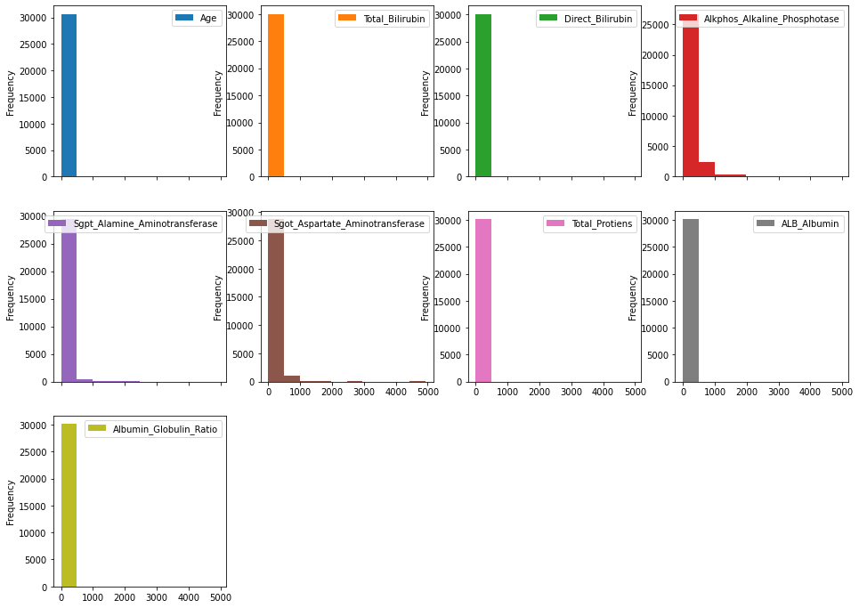

```python
# Histograms for each attribute
df_features_train.plot(kind='hist', subplots=True, layout=(display_rows, display_columns))
plt.show()
```

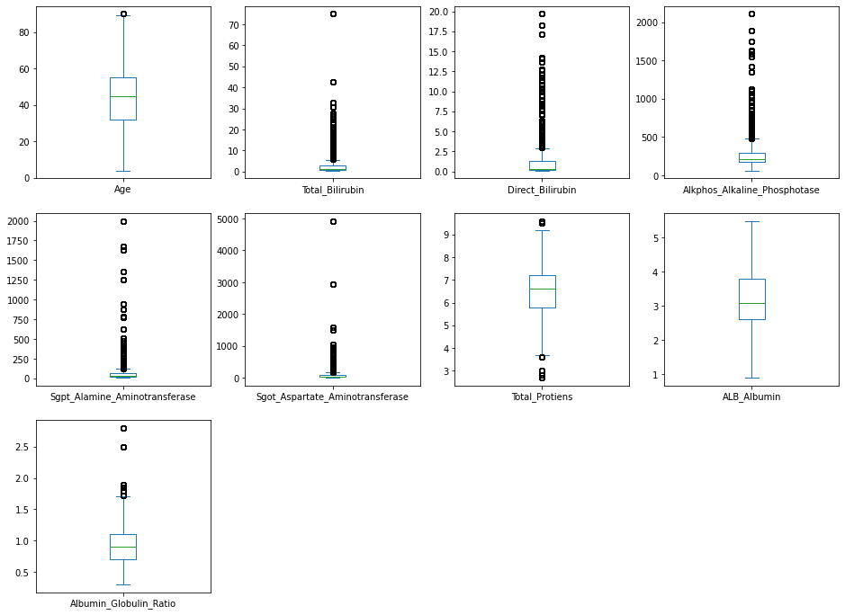

```python
# Box and Whisker plot for each attribute
df_features_train.plot(kind='box', subplots=True, layout=(display_rows, display_columns))
plt.show()
```

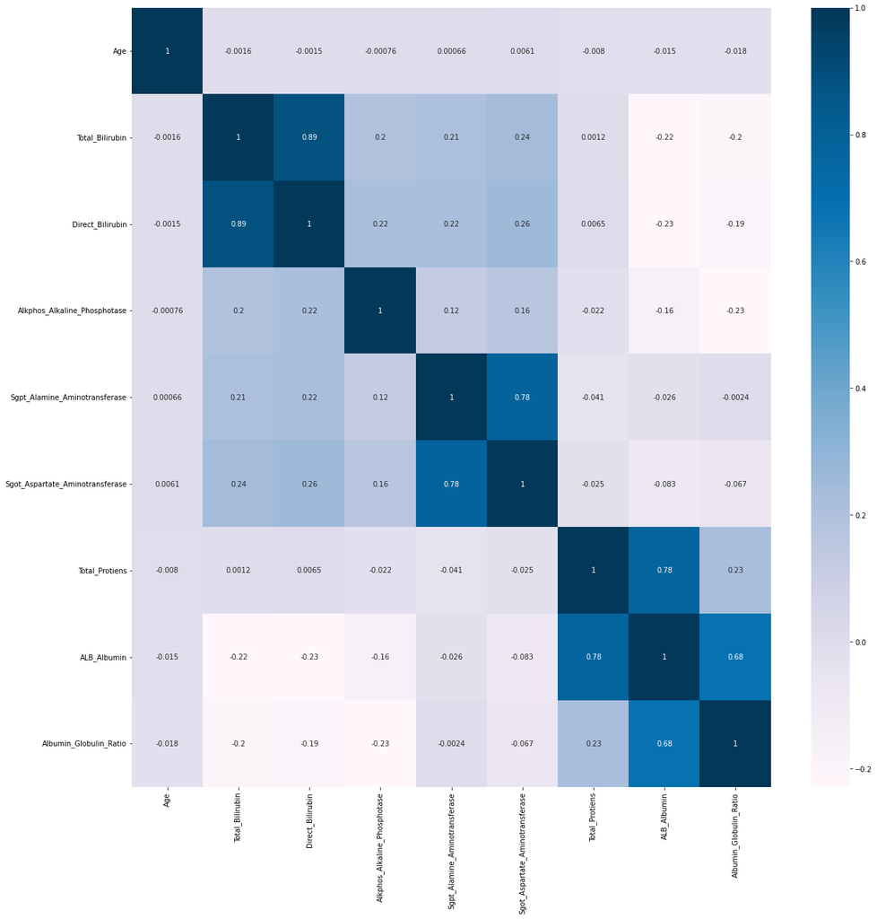

```python
# Correlation matrix
fig = plt.figure(figsize=(20, 20))
correlations = df_features_train.corr(method='pearson')
sns.heatmap(correlations, annot=True, cmap=plt.cm.PuBu)
plt.show()
```

```python
if NOTIFY_STATUS: status_notify("Task 2 - Summarize and Visualize Data completed! "+datetime.now().strftime('%a %B %d, %Y %I:%M:%S %p'))
```

## Task 3 - Train and Evaluate Models

```python
if NOTIFY_STATUS: status_notify("Task 3 - Train and Evaluate Models has begun! "+datetime.now().strftime('%a %B %d, %Y %I:%M:%S %p'))
```

### 3.a) Splitting Data into Training and Validation Sets

```python
# Finalize the training and validation datasets for the modeling activities
tfds_train = tfdf.keras.pd_dataframe_to_tf_dataset(df_dataset_import, label='target', task = tfdf.keras.Task.CLASSIFICATION)
```

### 3.b) Train and Evaluate the Random Forest Model

```python
# Initialize the default model and get a baseline result
start_time_module = datetime.now()
results = list()

# Splitting the dataset into a number of folds for cross-validation
cv = RepeatedKFold(n_splits=N_FOLDS, n_repeats=N_ITERATIONS, random_state=RNG_SEED)
split_sets = cv.split(df_dataset_import)

for i in range(N_FOLDS * N_ITERATIONS):
    # print('Training and evaluating for iteration:', i)
    cv_result = next(split_sets, None)
    # print(cv_result)
    df_dataset_train = df_dataset_import.iloc[cv_result[0]]
    df_dataset_test =  df_dataset_import.iloc[cv_result[1]]
    # print("df_dataset_import.shape: {} df_dataset_train.shape: {} df_dataset_test.shape: {}".format(df_dataset_import.shape, df_dataset_train.shape, df_dataset_test.shape))
    tfds_cv_train = tfdf.keras.pd_dataframe_to_tf_dataset(df_dataset_train, label='target', task = tfdf.keras.Task.CLASSIFICATION)
    tfds_cv_test = tfdf.keras.pd_dataframe_to_tf_dataset(df_dataset_test, label='target', task = tfdf.keras.Task.CLASSIFICATION)
    tf.keras.utils.set_random_seed(RNG_SEED)
    baseline1_model = tfdf.keras.RandomForestModel(task = tfdf.keras.Task.CLASSIFICATION)
    baseline1_model.compile(metrics=DEFAULT_METRICS)
    baseline1_model.fit(x=tfds_cv_train, verbose=0)
    baseline_eval = baseline1_model.evaluate(tfds_cv_test, verbose=0)
    model_metric = baseline_eval[1]
    print('Score from iteration %d >>> %.4f' % (i, model_metric))
    results.append(model_metric)
validation_score = np.mean(results)
validation_variance = np.std(results)
print('Average model score from all iterations: %.4f (%.4f)' % (validation_score, validation_variance))
print('Total time for model fitting and cross validating:', (datetime.now() - start_time_module))
```

```
Use /tmp/tmp04pe7qbe as temporary training directory
```

[output not shown]

```
WARNING: AutoGraph could not transform <function simple_ml_inference_op_with_handle at 0x7fa75146eb00> and will run it as-is.
Please report this to the TensorFlow team. When filing the bug, set the verbosity to 10 (on Linux, `export AUTOGRAPH_VERBOSITY=10`) and attach the full output.
Cause: could not get source code
To silence this warning, decorate the function with @tf.autograph.experimental.do_not_convert
Score from iteration 0 >>> 0.9935
Use /tmp/tmpjth07rkm as temporary training directory
Score from iteration 1 >>> 0.9925
Use /tmp/tmp4n0dq1_h as temporary training directory
Score from iteration 2 >>> 0.9948
Use /tmp/tmpmjob9rpm as temporary training directory
Score from iteration 3 >>> 0.9938
Use /tmp/tmph0nws__g as temporary training directory
```

[output not shown]

```
Score from iteration 4 >>> 0.9951
Use /tmp/tmpgjvtyqwh as temporary training directory
```

[output not shown]

```
Score from iteration 5 >>> 0.9919
Use /tmp/tmphaxj0p01 as temporary training directory
Score from iteration 6 >>> 0.9945
Use /tmp/tmpctnkv657 as temporary training directory
Score from iteration 7 >>> 0.9899
Use /tmp/tmp0dh25ccu as temporary training directory
Score from iteration 8 >>> 0.9902
Use /tmp/tmpj8jpi_jc as temporary training directory
Score from iteration 9 >>> 0.9932
Average model score from all iterations: 0.9929 (0.0017)
Total time for model fitting and cross validating: 0:01:50.797246
```

### 3.c) Train and Evaluate the Decision Trees Model

```python
# Initialize the default model and get a baseline result
start_time_module = datetime.now()
results = list()
cv = RepeatedKFold(n_splits=N_FOLDS, n_repeats=N_ITERATIONS, random_state=RNG_SEED)
split_sets = cv.split(df_dataset_import)

for i in range(N_FOLDS * N_ITERATIONS):
    # print('Training and evaluating for iteration:', i)
    cv_result = next(split_sets, None)
    # print(cv_result)
    df_dataset_train = df_dataset_import.iloc[cv_result[0]]
    df_dataset_test =  df_dataset_import.iloc[cv_result[1]]
    # print("df_dataset_import.shape: {} df_dataset_train.shape: {} df_dataset_test.shape: {}".format(df_dataset_import.shape, df_dataset_train.shape, df_dataset_test.shape))
    tfds_cv_train = tfdf.keras.pd_dataframe_to_tf_dataset(df_dataset_train, label='target', task = tfdf.keras.Task.CLASSIFICATION)
    tfds_cv_test = tfdf.keras.pd_dataframe_to_tf_dataset(df_dataset_test, label='target', task = tfdf.keras.Task.CLASSIFICATION)
    tf.keras.utils.set_random_seed(RNG_SEED)
    baseline2_model = tfdf.keras.CartModel(task = tfdf.keras.Task.CLASSIFICATION)
    baseline2_model.compile(metrics=DEFAULT_METRICS)
    baseline2_model.fit(x=tfds_cv_train, verbose=0)
    baseline_eval = baseline2_model.evaluate(tfds_cv_test, verbose=0)
    model_metric = baseline_eval[1]
    print('Score from iteration %d >>> %.4f' % (i, model_metric))
    results.append(model_metric)
validation_score = np.mean(results)
validation_variance = np.std(results)
print('Average model score from all iterations: %.4f (%.4f)' % (validation_score, validation_variance))
print('Total time for model fitting and cross validating:', (datetime.now() - start_time_module))
```

```
Use /tmp/tmpx2scmhvj as temporary training directory
Score from iteration 0 >>> 0.9726
Use /tmp/tmp535by8p0 as temporary training directory
Score from iteration 1 >>> 0.9456
Use /tmp/tmpix9lnxh7 as temporary training directory
Score from iteration 2 >>> 0.9075
Use /tmp/tmp07cjrlda as temporary training directory
Score from iteration 3 >>> 0.9638
Use /tmp/tmp2klvzkuf as temporary training directory
Score from iteration 4 >>> 0.9368
Use /tmp/tmpjwlnrm9q as temporary training directory
Score from iteration 5 >>> 0.9293
Use /tmp/tmpkjswm1q6 as temporary training directory
Score from iteration 6 >>> 0.9495
Use /tmp/tmphxbf2_cs as temporary training directory
Score from iteration 7 >>> 0.8892
Use /tmp/tmpzemwu5ng as temporary training directory
Score from iteration 8 >>> 0.9459
Use /tmp/tmpe0mungz7 as temporary training directory
Score from iteration 9 >>> 0.9211
Average model score from all iterations: 0.9361 (0.0240)
Total time for model fitting and cross validating: 0:00:07.172880
```

### 3.d) Train and Evaluate the Gradient Boosted Trees Model

```python
# Initialize the default model and get a baseline result
start_time_module = datetime.now()
results = list()
cv = RepeatedKFold(n_splits=N_FOLDS, n_repeats=N_ITERATIONS, random_state=RNG_SEED)
split_sets = cv.split(df_dataset_import)

for i in range(N_FOLDS * N_ITERATIONS):
    # print('Training and evaluating for iteration:', i)
    cv_result = next(split_sets, None)
    # print(cv_result)
    df_dataset_train = df_dataset_import.iloc[cv_result[0]]
    df_dataset_test =  df_dataset_import.iloc[cv_result[1]]
    # print("df_dataset_import.shape: {} df_dataset_train.shape: {} df_dataset_test.shape: {}".format(df_dataset_import.shape, df_dataset_train.shape, df_dataset_test.shape))
    tfds_cv_train = tfdf.keras.pd_dataframe_to_tf_dataset(df_dataset_train, label='target', task = tfdf.keras.Task.CLASSIFICATION)
    tfds_cv_test = tfdf.keras.pd_dataframe_to_tf_dataset(df_dataset_test, label='target', task = tfdf.keras.Task.CLASSIFICATION)
    tf.keras.utils.set_random_seed(RNG_SEED)
    baseline3_model = tfdf.keras.GradientBoostedTreesModel(task = tfdf.keras.Task.CLASSIFICATION)
    baseline3_model.compile(metrics=DEFAULT_METRICS)
    baseline3_model.fit(x=tfds_cv_train, verbose=0)
    baseline_eval = baseline3_model.evaluate(tfds_cv_test, verbose=0)
    model_metric = baseline_eval[1]
    print('Score from iteration %d >>> %.4f' % (i, model_metric))
    results.append(model_metric)
validation_score = np.mean(results)
validation_variance = np.std(results)
print('Average model score from all iterations: %.4f (%.4f)' % (validation_score, validation_variance))
print('Total time for model fitting and cross validating:', (datetime.now() - start_time_module))
```

```
Use /tmp/tmph2e45y46 as temporary training directory
Score from iteration 0 >>> 0.9990
Use /tmp/tmpo8h0dk6o as temporary training directory
Score from iteration 1 >>> 0.9974
Use /tmp/tmp61ret04w as temporary training directory
Score from iteration 2 >>> 0.9987
Use /tmp/tmp7qs86v1w as temporary training directory
Score from iteration 3 >>> 0.9993
Use /tmp/tmp1k5z883z as temporary training directory
Score from iteration 4 >>> 0.9974
Use /tmp/tmp4vhi51vj as temporary training directory
Score from iteration 5 >>> 0.9980
Use /tmp/tmpk27dqbag as temporary training directory
Score from iteration 6 >>> 0.9984
Use /tmp/tmprq7r_ljm as temporary training directory
Score from iteration 7 >>> 0.9974
Use /tmp/tmp8ira62p6 as temporary training directory
Score from iteration 8 >>> 0.9971
Use /tmp/tmpjeswg5iy as temporary training directory
Score from iteration 9 >>> 0.9980
Average model score from all iterations: 0.9981 (0.0007)
Total time for model fitting and cross validating: 0:06:12.223607
```

```python
if NOTIFY_STATUS: status_notify("Task 4 - Train and Evaluate Models completed! "+datetime.now().strftime('%a %B %d, %Y %I:%M:%S %p'))
```

## Task 4 - Fine-tune and Improve Models

```python
if NOTIFY_STATUS: status_notify("Task 4 - Fine-tune and Improve Models has begun! "+datetime.now().strftime('%a %B %d, %Y %I:%M:%S %p'))
```

```python
# Not applicable for this iteration of modeling
```

```python
if NOTIFY_STATUS: status_notify("Task 4 - Fine-tune and Improve Models completed! "+datetime.now().strftime('%a %B %d, %Y %I:%M:%S %p'))
```

## Task 5 - Finalize Model and Present Analysis

```python
if NOTIFY_STATUS: status_notify("Task 5 - Finalize Model and Present Analysis has begun! "+datetime.now().strftime('%a %B %d, %Y %I:%M:%S %p'))
```

```python
# Define the baseline model for benchmarking
start_time_module = datetime.now()
tf.keras.utils.set_random_seed(RNG_SEED)
# final_model = tfdf.keras.RandomForestModel(task = tfdf.keras.Task.CLASSIFICATION)
# final_model = tfdf.keras.CartModel(task = tfdf.keras.Task.CLASSIFICATION)
final_model = tfdf.keras.GradientBoostedTreesModel(task = tfdf.keras.Task.CLASSIFICATION)

# Optionally, add evaluation metrics.
final_model.compile(metrics=DEFAULT_METRICS)

# "sys_pipes" is optional. It enables the display of the training logs.
# with sys_pipes():
#     final_model.fit(x=tfds_train)

# Train the model.
final_model.fit(x=tfds_train)
print ('Model training time:', (datetime.now() - start_time_module), '\n')
```

```
Use /tmp/tmposva4ec3 as temporary training directory
Reading training dataset...
Training dataset read in 0:00:00.345101. Found 30691 examples.
Training model...
Model trained in 0:00:37.953261
Compiling model...
Model compiled.
Model training time: 0:00:41.207187
```

```python
final_model.summary()
```

```
Model: "gradient_boosted_trees_model_10"
_________________________________________________________________
 Layer (type)                Output Shape              Param #
=================================================================
=================================================================
Total params: 1
Trainable params: 0
Non-trainable params: 1
_________________________________________________________________
Type: "GRADIENT_BOOSTED_TREES"
Task: CLASSIFICATION
Label: "__LABEL"

Input Features (10):
	ALB_Albumin
	Age
	Albumin_Globulin_Ratio
	Alkphos_Alkaline_Phosphotase
	Direct_Bilirubin
	Gender
	Sgot_Aspartate_Aminotransferase
	Sgpt_Alamine_Aminotransferase
	Total_Bilirubin
	Total_Protiens

No weights

Variable Importance: MEAN_MIN_DEPTH:
    1.                         "__LABEL"  4.892666 ################
    2.                          "Gender"  4.830492 ###############
    3.                             "Age"  4.458877 ############
    4.                 "Total_Bilirubin"  4.106989 ##########
    5.                  "Total_Protiens"  3.859110 ########
    6.          "Albumin_Globulin_Ratio"  3.844187 ########
    7.                     "ALB_Albumin"  3.739505 #######
    8.                "Direct_Bilirubin"  3.450828 #####
    9. "Sgot_Aspartate_Aminotransferase"  3.215646 ###
   10.   "Sgpt_Alamine_Aminotransferase"  3.102395 ##
   11.    "Alkphos_Alkaline_Phosphotase"  2.779391

```

[output cut: 175 more lines]

```
	24704 : HigherCondition
	367 : ContainsBitmapCondition
Condition type in nodes with depth <= 0:
	900 : HigherCondition
Condition type in nodes with depth <= 1:
	2698 : HigherCondition
Condition type in nodes with depth <= 2:
	6185 : HigherCondition
	55 : ContainsBitmapCondition
Condition type in nodes with depth <= 3:
	12740 : HigherCondition
	140 : ContainsBitmapCondition
Condition type in nodes with depth <= 5:
	24704 : HigherCondition
	367 : ContainsBitmapCondition
```

```python
if NOTIFY_STATUS: status_notify("Task 5 - Finalize Model and Present Analysis completed! "+datetime.now().strftime('%a %B %d, %Y %I:%M:%S %p'))
```

```python
print ('Total time for the script:',(datetime.now() - start_time_script))
```

```
Total time for the script: 0:08:57.394201
```